# Day 2 Part 1: Fitting Volatility Models

Zero to Hero Bootcamp - Time Series Econometrics in R

Author

Dr Christian Engels

Last updated

November 22, 2024

## Introduction

In this session, we will focus on fitting various volatility models to financial time series data, specifically the S&P 500 index. We will:

- Download and prepare the S&P 500 data.
- Perform exploratory data analysis (EDA).
- Fit different GARCH models.
- Evaluate model diagnostics.
- Forecast future volatility.
- Calculate Value at Risk (VaR) and Expected Shortfall (ES).

## Loading Required Libraries

First, we load the necessary R packages for data manipulation, time series analysis, and modeling.

```r
library(tidyverse)     # Data manipulation and visualization
library(tidyfinance)   # Financial data tools
library(tsibble)       # Time series data manipulation
library(fable)         # Time series modeling
library(feasts)        # Time series features
library(rugarch)       # Univariate GARCH models
library(forecast)      # Forecasting functions
```

## Data Acquisition and Preparation

We will work with the S&P 500 index data. If the data file does not exist locally, we download it using the `download_data` function; otherwise, we read it from the existing CSV file.

```r
if (!file.exists("sp500_index.csv")) {
  sp500_download <-
    download_data(
      "stock_prices",
      symbols = "^GSPC",
      start_date = "2014-11-18",
      end_date = "2024-11-18"
    )
  sp500_download %>% write_csv("sp500_index.csv")
} else {
  sp500_download <- read_csv("sp500_index.csv")
}
```

### Calculating Returns

We calculate the daily returns of the S&P 500 index from the adjusted closing prices.

```r
sp500_returns <-
  sp500_download %>%
  select(symbol, date, price = adjusted_close) %>%
  mutate(return = price / lag(price) - 1) %>%
  remove_missing() %>%
  select(-price) %>%
  mutate(date = row_number()) %>%
  print()
```

```
# A tibble: 2,515 × 3
   symbol  date   return
   <chr>  <int>    <dbl>
 1 ^GSPC      1 -0.00150
 2 ^GSPC      2  0.00197
 3 ^GSPC      3  0.00524
 4 ^GSPC      4  0.00286
 5 ^GSPC      5 -0.00115
 6 ^GSPC      6  0.00281
 7 ^GSPC      7 -0.00254
 8 ^GSPC      8 -0.00683
 9 ^GSPC      9  0.00638
10 ^GSPC     10  0.00376
# ℹ 2,505 more rows
```

## Exploratory Data Analysis

### Plotting Returns

We visualize the daily returns over time to observe any patterns or anomalies.

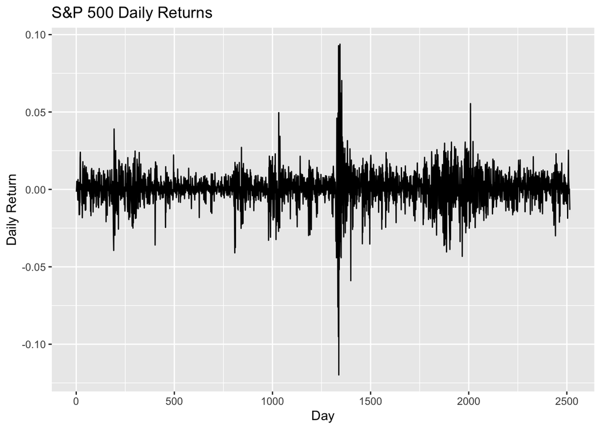

```r
sp500_returns %>%
  ggplot(aes(x = date, y = return)) +
  geom_line() +
  labs(
    title = "S&P 500 Daily Returns",
    x = "Day",
    y = "Daily Return"
  )
```

### Statistical Summary

We compute key statistical measures to understand the distribution of returns.

```r
sp500_stats <-
  sp500_returns %>%
  summarise(
    mean_return = mean(return),
    std_dev = sd(return),
    skewness = moments::skewness(return),
    kurtosis = moments::kurtosis(return),
    jarque_bera_pvalue = tseries::jarque.bera.test(return)$p.value
  )

sp500_stats
```

```
# A tibble: 1 × 5
  mean_return std_dev skewness kurtosis jarque_bera_pvalue
        <dbl>   <dbl>    <dbl>    <dbl>              <dbl>
1    0.000481  0.0112   -0.517     17.5                  0
```

### Return Distribution

We compare the empirical distribution of returns to the normal distribution.

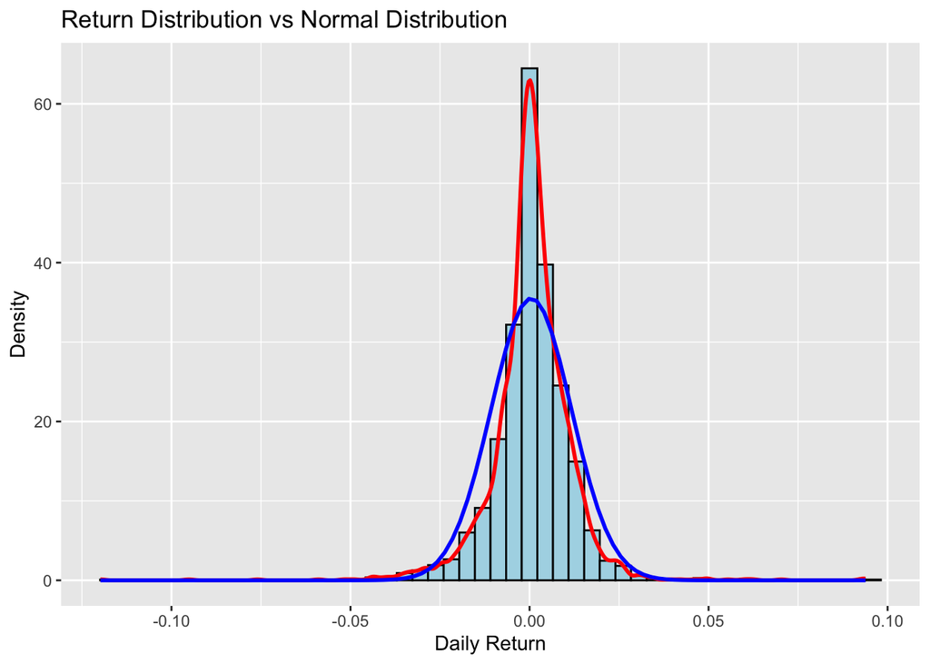

```r
sp500_returns %>%
  ggplot(aes(x = return)) +
  geom_histogram(aes(y = ..density..), bins = 50, fill = "lightblue", color = "black") +
  geom_density(color = "red", size = 1) +
  stat_function(
    fun = dnorm,
    args = list(
      mean = mean(sp500_returns$return),
      sd = sd(sp500_returns$return)
    ),
    color = "blue",
    size = 1
  ) +
  labs(
    title = "Return Distribution vs Normal Distribution",
    x = "Daily Return",
    y = "Density"
  )
```

### Time Series Characteristics

We examine the autocorrelation and partial autocorrelation of the returns.

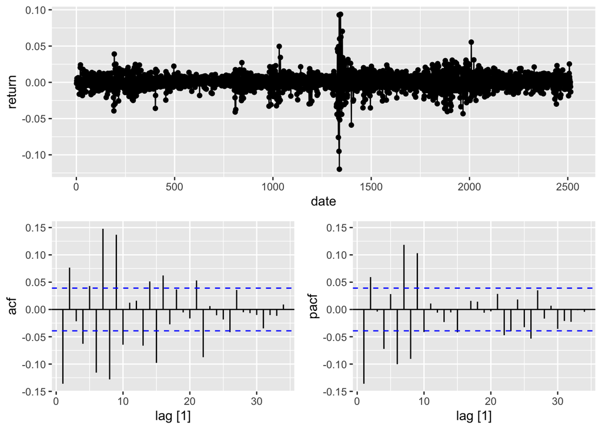

```r
sp500_returns %>%
  as_tsibble(index = date) %>%
  gg_tsdisplay(return, plot_type = "partial")
```

## Modeling Volatility

### Fitting an ARIMA Model

We fit an ARIMA model to the returns to capture any autoregressive patterns.

```r
fit_auto_arima <-
  sp500_returns %>%
  as_tsibble(index = date) %>%
  model(arima = ARIMA(return))
fit_auto_arima
```

```
# A mable: 1 x 1
                   arima
                 <model>
1 <ARIMA(2,0,2) w/ mean>
```

### Specifying GARCH and ARMA Orders

We define the orders for the GARCH and ARMA components.

```r
garch_order <- c(2, 2)  # GARCH(p,q) order
arma_order <- c(2, 2)   # ARMA(p,q) order
```

### Defining GARCH Model Specifications

We specify multiple GARCH models to compare their performance.

```r
garch_specs <-
  list(
    # Standard GARCH model specification
    sGARCH = ugarchspec(
      variance.model = list(
        model = "sGARCH",
        garchOrder = garch_order
      ),
      mean.model = list(
        armaOrder = arma_order,
        include.mean = TRUE
      ),
      distribution.model = "std"  # Student's t-distribution
    ),
    # Asymmetric Power ARCH model specification
    apARCH = ugarchspec(
      variance.model = list(
        model = "apARCH",
        garchOrder = garch_order
      ),
      mean.model = list(
        armaOrder = arma_order,
        include.mean = TRUE
      ),
      distribution.model = "std"
    ),
    # GJR-GARCH model specification
    gjrGARCH = ugarchspec(
      variance.model = list(
        model = "gjrGARCH",
        garchOrder = garch_order
      ),
      mean.model = list(
        armaOrder = arma_order,
        include.mean = TRUE
      ),
      distribution.model = "std"
    ),
    # Threshold GARCH (TGARCH) model specification
    tGARCH = ugarchspec(
      variance.model = list(
        model = "fGARCH",
        submodel = "TGARCH",
        garchOrder = garch_order
      ),
      mean.model = list(
        armaOrder = arma_order,
        include.mean = TRUE
      ),
      distribution.model = "std"
    )
  )
```

### Fitting the GARCH Models

We fit each GARCH model to the returns data.

```r
fit_results <-
  map(
    garch_specs,
    ~ ugarchfit(spec = .x, data = sp500_returns$return)
  )
```

## Model Diagnostics

### Defining a Diagnostic Function

We create a function to extract important diagnostic statistics from each model.

```r
get_model_diagnostics <- function(model) {
  tibble(
    aic = infocriteria(model)[1],
    bic = infocriteria(model)[2],
    log_likelihood = likelihood(model),
    persistence = persistence(model),
    half_life = -log(2) / log(persistence(model)),
    unconditional_variance = mean(sigma(model)^2)
  )
}
```

### Comparing Model Statistics

We apply the diagnostic function to each model and compile the results.

```r
fit_stats <- map_dfr(fit_results, get_model_diagnostics, .id = "model")
fit_stats
```

```
# A tibble: 4 × 7
  model    aic   bic log_likelihood persistence half_life unconditional_variance
  <chr>  <dbl> <dbl>          <dbl>       <dbl>     <dbl>                  <dbl>
1 sGARCH -6.70 -6.67          8436.       0.997     201.                0.000136
2 apARCH -6.74 -6.71          8495.       0.964      18.9               0.000132
3 gjrGA… -6.73 -6.70          8477.       0.987      53.4               0.000141
4 tGARCH -6.75 -6.72          8500.       0.942      11.5               0.000135
```

### Analyzing Residuals

We extract standardized residuals to check for remaining autocorrelation or patterns.

```r
residuals <-
  imap_dfr(
    fit_results,
    ~ tibble(
      model = .y,
      date = sp500_returns$date,
      residuals = residuals(.x, standardize = TRUE) %>% as.numeric()
    )
  )
residuals
```

```
# A tibble: 10,060 × 3
   model   date residuals
   <chr>  <int>     <dbl>
 1 sGARCH     1   -0.215
 2 sGARCH     2    0.0943
 3 sGARCH     3    0.455
 4 sGARCH     4    0.206
 5 sGARCH     5   -0.250
 6 sGARCH     6    0.233
 7 sGARCH     7   -0.481
 8 sGARCH     8   -1.08
 9 sGARCH     9    0.773
10 sGARCH    10    0.396
# ℹ 10,050 more rows
```

### Plotting Squared Residuals

We plot the squared standardized residuals to assess the adequacy of the volatility models.

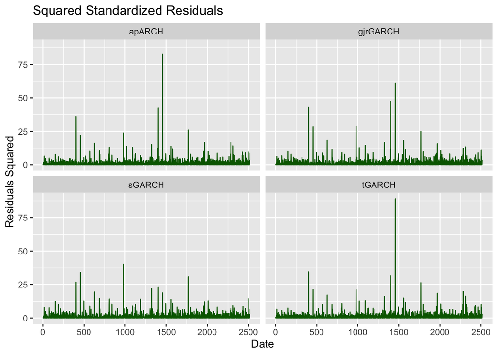

```r
residuals %>%
  ggplot(aes(x = date, y = residuals^2)) +
  geom_line(color = "darkgreen") +
  labs(
    title = "Squared Standardized Residuals",
    x = "Date",
    y = "Residuals Squared"
  ) +
  facet_wrap(~model)
```

### Residual Diagnostics for tGARCH Model

We perform time series diagnostics on the residuals of the tGARCH model.

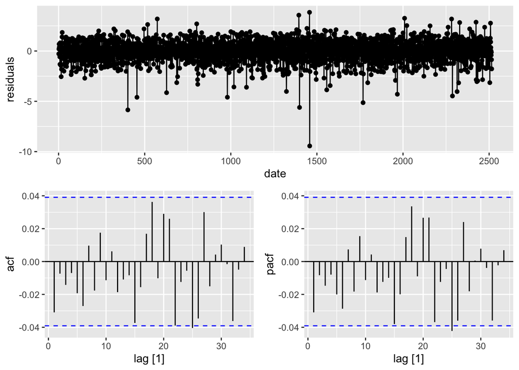

```r
residuals %>%
  filter(model == "tGARCH") %>%
  as_tsibble(index = date) %>%
  gg_tsdisplay(residuals, plot_type = "partial")
```

## Forecasting Volatility

### Generating Volatility Forecasts

We forecast the future volatility over the next 30 days using each model.

```r
n_ahead <- 30  # Number of days to forecast
forecasts <- map(
  fit_results,
  ~ ugarchforecast(.x, n.ahead = n_ahead)
)
```

### Preparing Forecast Data

We extract the forecasted volatility and compute confidence intervals.

```r
forecast_data <-
  map2_df(
    forecasts, names(forecasts),
    ~ {
      sigma_forecast <- sigma(.x) %>% as.numeric()
      conf_intervals <- qnorm(c(0.025, 0.975)) * sigma_forecast
      tibble(
        Day = 1:n_ahead,
        Forecasted_Volatility = sigma_forecast,
        Lower_CI = sigma_forecast + conf_intervals[1],
        Upper_CI = sigma_forecast + conf_intervals[2],
        Model = .y
      )
    }
  )
```

### Plotting Forecasted Volatility

We visualize the forecasted volatility for each model.

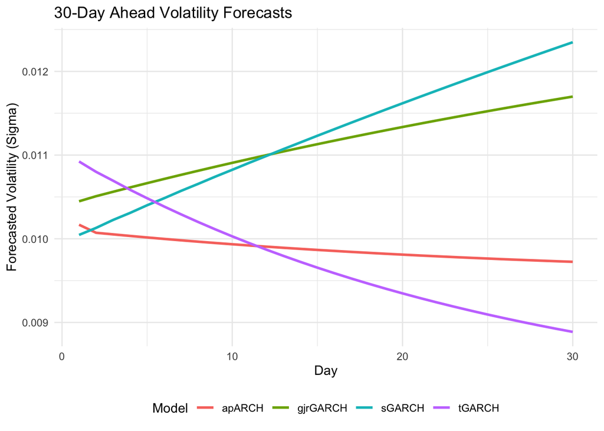

```r
ggplot(forecast_data, aes(x = Day, y = Forecasted_Volatility, color = Model)) +
  geom_line(linewidth = 1) +
  labs(
    title = "30-Day Ahead Volatility Forecasts",
    x = "Day",
    y = "Forecasted Volatility (Sigma)"
  ) +
  theme_minimal() +
  theme(legend.position = "bottom")
```

## Risk Assessment: VaR and ES

### Calculating VaR and ES

We compute the Value at Risk (VaR) and Expected Shortfall (ES) at the 95% confidence level for each model.

```r
alpha <- 0.05  # 95% confidence level

# Iterate over forecasts and fitted models
var_forecasts <- map2_dfr(forecasts, fit_results, function(forecast, model) {
  # Extract mean and standard deviation from the forecast
  mu <- as.numeric(fitted(forecast))[1]
  sigma <- as.numeric(sigma(forecast))[1]

  # Extract the shape parameter (degrees of freedom)
  shape <- as.numeric(coef(model)["shape"])

  # Calculate VaR using the t-distribution quantile
  var_95 <- mu + sigma * qt(alpha, df = shape)

  # Calculate ES (Expected Shortfall)
  qt_value <- qt(alpha, df = shape)
  dt_value <- dt(qt_value, df = shape)
  es_95 <- mu - sigma * (dt_value / alpha) * (shape + qt_value^2) / (shape - 1)

  tibble(
    Model = model@model$modeldesc$vmodel,
    VaR_95 = var_95,
    ES_95 = es_95
  )
}, .id = "model")
```

### Displaying Risk Measures

We present the calculated VaR and ES for each volatility model.

```r
var_forecasts
```

```
# A tibble: 4 × 4
  model    Model     VaR_95   ES_95
  <chr>    <chr>      <dbl>   <dbl>
1 sGARCH   sGARCH   -0.0192 -0.0272
2 apARCH   apARCH   -0.0194 -0.0269
3 gjrGARCH gjrGARCH -0.0201 -0.0282
4 tGARCH   fGARCH   -0.0209 -0.0291
```

## Conclusion

In this session, we:

- Collected and prepared S&P 500 index data.
- Performed exploratory data analysis to understand the return characteristics.
- Specified and fitted various GARCH models to capture volatility clustering and leverage effects.
- Evaluated model diagnostics to select the most appropriate model.
- Forecasted future volatility over a 30-day horizon.
- Calculated risk measures such as Value at Risk (VaR) and Expected Shortfall (ES) to assess potential losses.

This comprehensive approach demonstrates how volatility modeling is crucial in financial econometrics for risk management and forecasting.